# Figures from Plasticity and Artificial Selection for Developmental Mode in a Poecilogonous Sea Slug

This Rmarkdown document contains the figures and code for figures in the MS Plasticity and Artificial Selection for Developmental Mode in a Poecilogonous Sea Slug published in Evolution and Ecology in 2021

# Figure 1

Figure one is a schematic of the study design and was made in powerpoint (with lots of copying and pasting).

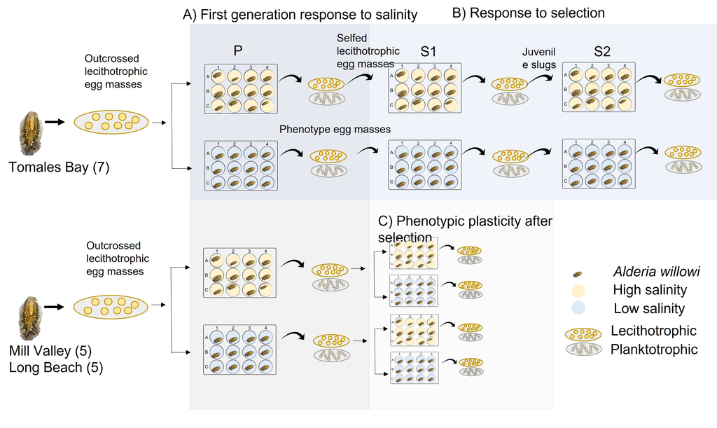

Schematic showing the layout of two split-brood experiments the data for which addresses three main points. The first-generation response to salinity (A) uses pooled data from both experiments. The response to selection (B) was estimated from the first experiment using 7 maternal families collected from Tomales Bay. In the second experiment I evaluate the effect to plasticity following one generation of selection (C) and self-fertilization in low and high salinity using maternal families from Mill Valley and Long Beach.

# Figure 2

Figure two combines images of the study species with a scatterplot made in R. While I could combine them in R, I made the final figure in powerpoint. And that’s okay.

The code for the scatterplot is included at the end of this document.

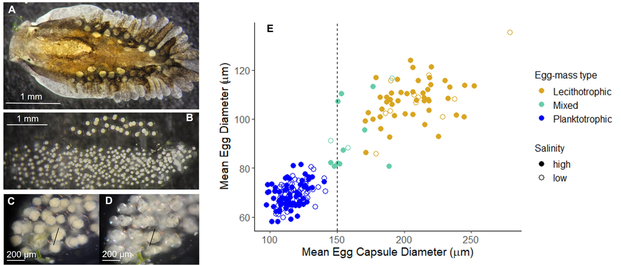

Images showing the study organism, the sacoglossan sea slug Alderia willowi (A). The two types of egg-masses produced by this species with a lecithotrophic egg-mass above a planktotrophic egg-mass (B). Egg capsule size is constant through development. Panel C and D show the same embryo at the 32-64 cell stage (C) and 4 days later at the veliger stage (D). At each time the egg capsule was measured to be 206 µm. Panel (E) shows that the relationship between mean egg diameter and mean egg-capsule diameter for a given egg-mass, is positive (r-squared = 85, p-value < 2.2e-16). Salinity doesn’t change the range in egg diameter or egg capsule size but does shift the proportion of egg-mass type. All images were taken by the author.